# Problem Set 07

SOLUTIONS

You can access the .Rmd for the solutions [here](https://github.com/kgfitzgerald/APU_MATH_362/blob/main/PROBLEM_SETS/SOLUTIONS/PS-07-SOLUTIONS.Rmd).

## Summary / Reflection Prompts

*RP1: What were the main concepts covered in this assignment?*

*RP2: What’s one thing you understand better after completing these problems?*

*RP3: What problems gave you the most trouble? What was difficult about them/where did you get stuck?*

*RP4: What questions and/or reflections do you have regarding the read & reflect section?*

# By hand or typed

## Exercise 1

$$\begin{aligned}
L(\theta) &= P(X = x_1, X= x_2, \dots, X = x_{10}) = \prod_{i =
1}^nf(x_i;\theta) \\
&= P(X = 3)P(X = 0)P(X = 2)P(X = 1)P(X = 3)P(X = 2)P(X = 1)P(X =
0)P(X = 2)P(X = 1)\\
&= [P(X=0)]^2[P(X=1)]^3[P(X=2)]^3[P(X=3)]^2\\
&=
\frac{2^2}{3^2}\theta^2\frac{1^3}{3^3}\theta^3\frac{2^3}{3^3}(1-\theta)^3\frac{1^2}{3^2}(1-\theta)^2\\
&=\frac{2^5}{3^{10}}\theta^5(1-\theta)^5\\
logL(\theta) &= log\left(\frac{2^5}{3^{10}}\right) + 5log(\theta) +
5log(1-\theta)\\
\frac{\partial logL(\theta)}{\partial \theta} &= \frac{5}{\theta} -
\frac{5}{1 - \theta} \overset{\text{SET}}{=} 0 \\
\end{aligned}$$

Solving for $\theta$ yields an MLE of $\hat{\theta} = \frac{1}{2}$

## Exercise 2

$$\begin{aligned}
L(p) &= \prod_{i = 1}^n f(x_i; p)\\
&= \prod_{i = 1}^n p(1-p)^{x_i - 1} \\
&= p^n(1-p)^{\sum x_i - n}\\
logL(p) &= nlog(p) + (\sum_{i = 1}^nx_i - n)log(1-p)\\
\frac{\partial logL(p)}{\partial p} &= \frac{n}{p} - \frac{\sum_{i =
1}^nx_i - n}{1 - p}
\end{aligned}$$

Setting the above expression equal to 0, finding a common denominator, and solving for p, we get

$$\begin{aligned}
(1-p)n - p(\sum_{i = 1}^nx_i - n) &= 0\\
n - np - p\sum_{i = 1}^nx_i + np &= 0 \\
n &= p\sum_{i = 1}^nx_i\\
1 = p\overline{x}\\
\frac{1}{\overline{x}} = p
\end{aligned}$$

Therefore, the MLE of $p$ for a geometric distribution is $\hat{p}_{MLE} = \frac{1}{\overline{x}}$

# Typed

## Exercise 3

To show if an estimator $\hat{\theta}$ is unbiased, we can:

1. draw repeated samples (e.g. 10,000) from the population
2. compute a value for $\hat{\theta}$ at each iteration, using the formula for the estimator
3. plot the 10,000 $\hat{\theta}$ values and see if they are centered at $\theta$
4. compute the empirical expected value of $\hat{\theta}$ by taking the average of the 10,000 values, and compare it to $\theta$

If the empirical expected value of the 10,000 $\hat{\theta}$ values is equal to $\theta$ (plus or minus some simulation error), that is evidence that $\hat{\theta}$ is an unbiased estimator of $\theta$.

The above procedure would be done for each of the three estimators in question.

## Exercise 4

Code provided:

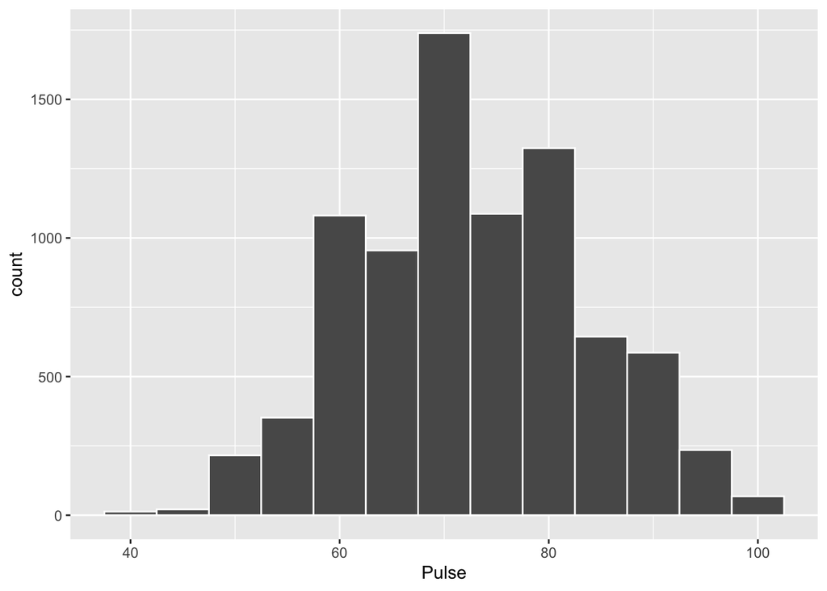

```r
library(tidyverse)
library(NHANES)
library(infer)

#create population data
population <- NHANES %>%
  filter(!is.na(Pulse), Pulse < 100)

#plot population distribution of variable of interest
ggplot(population, aes(x = Pulse)) +
  geom_histogram(color = "white", binwidth = 5)
```

```r
#compute and store population mean and variance
mu <- mean(population$Pulse)
mu
```

```
## [1] 72.63093
```

```r
sigma2 <- var(population$Pulse)
sigma2
```

```
## [1] 120.2072
```

```r
#set seed and draw 100,000 random samples of size 30
set.seed(437)
sims <- population %>%
  rep_sample_n(size = 30, reps = 100000)
```

Rest of solutions:

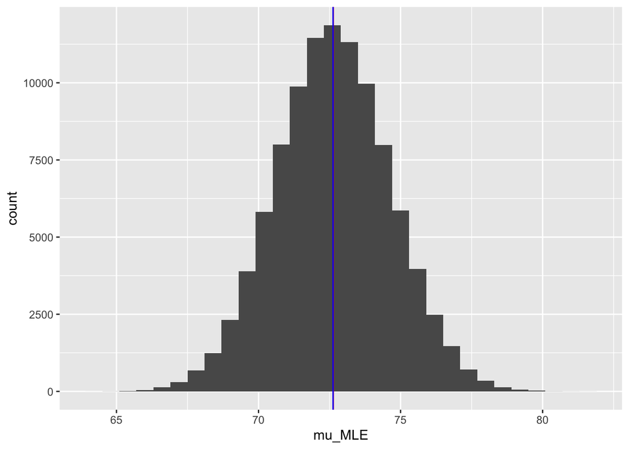

```r
#compute a value for each of the three estimators for each random sample
#sample_stats will have 100,000 rows and 4 variables
sample_stats <- sims %>%
  group_by(replicate) %>%
  summarize(mu_MLE = sum(Pulse)/n(),
         sigma2_MLE = sum((Pulse - sum(Pulse)/n())^2)/n(),
         S2 = sum((Pulse - sum(Pulse)/n())^2)/(n() - 1))

#compute empirical expected values of each estimator
Emu_MLE <- mean(sample_stats$mu_MLE)
Esigma2_MLE <- mean(sample_stats$sigma2_MLE)
ES2 <- mean(sample_stats$S2)

#plot sampling distributions with true parameter value marked in red
#and empirical expected value marked in blue
#red visible indicates estimator is biased
#red invisible (covered by blue) indicates estimator is unbiased
ggplot(sample_stats, aes(x = mu_MLE)) +
  geom_histogram() +
  geom_vline(xintercept = mu, color = "red") +
  geom_vline(xintercept = Emu_MLE, color = "blue")
```

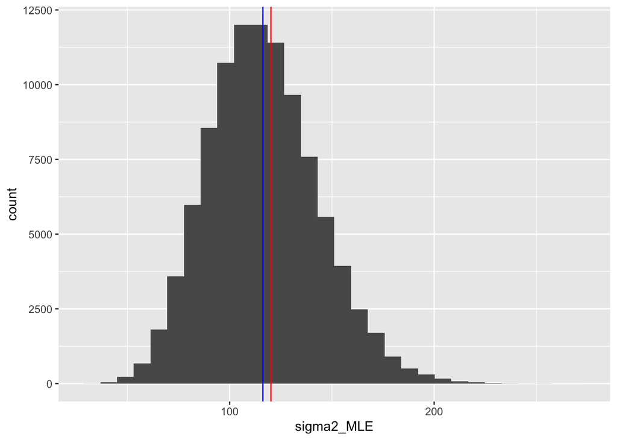

```r
ggplot(sample_stats, aes(x = sigma2_MLE)) +
  geom_histogram() +
  geom_vline(xintercept = sigma2, color = "red") +
  geom_vline(xintercept = Esigma2_MLE, color = "blue")
```

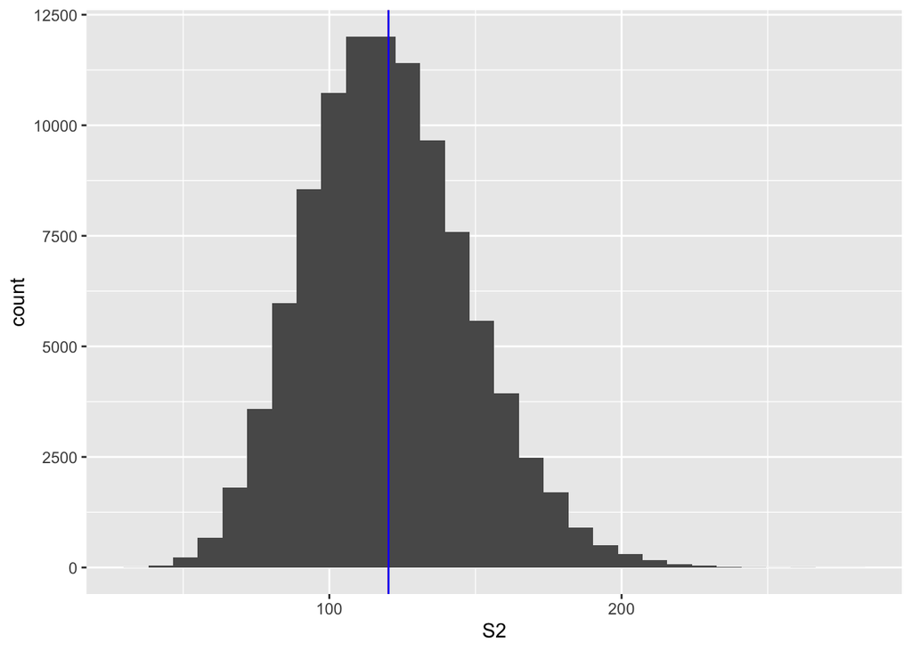

```r
ggplot(sample_stats, aes(x = S2)) +
  geom_histogram() +
  geom_vline(xintercept = sigma2, color = "red") +
  geom_vline(xintercept = ES2, color = "blue")
```